# Early Antibiotic Administration and Improved Outcomes in Sepsis Treatment: A MIMIC-IV Analysis

BMIN5030 Final Project

Author

Yuxuan Shi

## 1 Overview

This project primarily investigates the association between early antibiotic administration and patient outcomes among ICU patients diagnosed with sepsis using the MIMIC-IV dataset. The study aims to evaluate whether earlier intervention is associated with improved outcomes which is defined through a range of metrics, such as in-hospital mortality rate, 30-day readmission rate, ventilator-free days, and organ dysfunction progression. The goal is to identify potential clinical implications for optimizing the sepsis management processes. Some of these discrepancies stem from challenges in accurately defining the onset of sepsis, handling the time discretization for data analysis, or confounding factors such as illness severity and treatment bias.

## 2 Introduction

Sepsis is a leading cause of death in intensive care units (ICUs) and continues to pose major challenges to clinicians due to its complexity. Early antibiotic administration has long been considered a cornerstone of sepsis treatment, based on evidence suggesting that delays in treatment may increase mortality and worsen organ function. However, the optimal timing of antibiotic administration remains controversial, as observational studies have produced mixed results.

This project is interdisciplinary, combining insights from biomedical informatics, clinical medicine, and data science. From a clinical perspective, the project draws on principles of critical care and infectious disease management to define sepsis onset, select relevant outcomes, and interpret physiological indicators such as acuity scores (e.g. SOFA) trajectories; from a informatics standpoint, it involves working with high-dimensional EHR data and addressing issues such as timestep discretization and alignment, causal inference modeling, and other data science practices for various data processing tasks.

## 3 Methods

To systematically investigate the relationship between early antibiotic administration and patient outcomes among ICU patients with sepsis, this study follows a structured analytic pipeline integrating cohort filtering, feature construction, temporal alignment, data pre-processing, and modeling. Note that the MIMIC-IV v3.1 database is a large-scale critical care dataset containing information on over 300,000 hospital admissions and 60,000 ICU stays from the Beth Israel Deaconess Medical Center between 2008 and 2019, encompassing millions of clinical observations, laboratory results, and charted events. While thorough and more informative, the large-scale dataset might not be suitable for proof of concept and fast iterations at early stage. In comparison, MIMIC-IV Clinical Database Demo contains only a subset of (approximately 1% of) the full data, designed to preserve the same schema and data structure while greatly reducing the volume. Hence, this study initially develops and validates the pipeline using the demo dataset, and once functional integrity and performance are confirmed, the entire pipeline will be transplanted to process the full MIMIC-IV v3.1 dataset. The overall workflow is designed as follow.

### 3.1 Cohort Filtering

Patients will be excluded if they have missing antibiotic administration time stamps, lack key outcome data (e.g. discharge status), or have ICU stays shorter than 24 hours. This ensures temporal analyses are reliable and outcomes are meaningful for comparison.

### 3.2 Feature Construction

Key variables will be constructed across multiple tables within MIMIC-IV.

- 1) Demographic/General Features: Age, gender, ethnicity from *patients* and *admissions*.
- 2) Clinical Characteristics: Baseline SOFA scores, comorbidities (Using the Charlson Comobidity Index), vital signals from *chartevents* and *diagnoses_icd*, Microbiology-based infection detection from *microbiologyevents.*
- 3) Treatment Variables: Timing and dosage of first antibiotic administration, vasopressor use, and mechanical ventilation extracted from *prescriptions*, *inputevents*, and *procedureevents*.
- 4) Outcome Variables: In-hospital mortality, 30-day readmission, ventilator-free days, and organ dysfunction progression derived from *admissions*, *icustays*, and longitudinal *chartevents*.

In summary, tables being sourced are:

- X: *patients, admissions, chartevents, labevents, diagnoses_icd, icustays, prescriptions, inputevents, procedureevents*
- y: *admissions.discharge_location, admissions.admittime, procedureevents, chartevents*

```r
library(tidyverse)
```

```r
data_dir <- "./physionet.org/files/mimic-iv-demo/2.2"

# loading in the demo dataset
load_mimic <- function(path) {
  read_csv(file.path(data_dir, path), show_col_types = FALSE)
}

patients <- load_mimic("hosp/patients.csv.gz")
admissions <- load_mimic("hosp/admissions.csv.gz")
icustays <- load_mimic("icu/icustays.csv.gz")
chartevents <- load_mimic("icu/chartevents.csv.gz")
labevents <- load_mimic("hosp/labevents.csv.gz")
diagnoses_icd <- load_mimic("hosp/diagnoses_icd.csv.gz")
prescriptions <- load_mimic("hosp/prescriptions.csv.gz")
inputevents <- load_mimic("icu/inputevents.csv.gz")
procedureevents <- load_mimic("icu/procedureevents.csv.gz")
emar <- load_mimic("hosp/emar.csv.gz")
microbiologyevents <- load_mimic("hosp/microbiologyevents.csv.gz")
d_items <- load_mimic("icu/d_items.csv.gz")
d_labitems <- load_mimic("hosp/d_labitems.csv.gz")
outputevents <- load_mimic("icu/outputevents.csv.gz")


mimic_demo <- list(
  patients = patients,
  admissions = admissions,
  icustays = icustays,
  chartevents = chartevents,
  labevents = labevents,
  diagnoses_icd = diagnoses_icd,
  prescriptions = prescriptions,
  inputevents = inputevents,
  procedureevents = procedureevents,
  emar = emar,
  microbiologyevents <- microbiologyevents,
  d_items = d_items,
  d_labitems = d_labitems,
  outputevents <- outputevents
)
```

```r
mimic_demo
```

```
$patients
# A tibble: 100 × 6
   subject_id gender anchor_age anchor_year anchor_year_group dod
        <dbl> <chr>       <dbl>       <dbl> <chr>             <date>
 1   10014729 F              21        2125 2011 - 2013       NA
 2   10003400 F              72        2134 2011 - 2013       2137-09-02
 3   10002428 F              80        2155 2011 - 2013       NA
 4   10032725 F              38        2143 2011 - 2013       2143-03-30
 5   10027445 F              48        2142 2011 - 2013       2146-02-09
 6   10037928 F              78        2175 2011 - 2013       NA
 7   10001725 F              46        2110 2011 - 2013       NA
 8   10040025 F              64        2143 2011 - 2013       2148-02-07
 9   10008454 F              26        2110 2011 - 2013       NA
10   10020640 F              91        2153 2011 - 2013       2154-02-04
# ℹ 90 more rows

$admissions
# A tibble: 275 × 16
   subject_id  hadm_id admittime           dischtime
        <dbl>    <dbl> <dttm>              <dttm>
 1   10004235 24181354 2196-02-24 14:38:00 2196-03-04 14:02:00
 2   10009628 25926192 2153-09-17 17:08:00 2153-09-25 13:20:00
 3   10018081 23983182 2134-08-18 02:02:00 2134-08-23 19:35:00
 4   10006053 22942076 2111-11-13 23:39:00 2111-11-15 17:20:00
 5   10031404 21606243 2113-08-04 18:46:00 2113-08-06 20:57:00
 6   10005817 20626031 2132-12-12 01:43:00 2132-12-20 15:04:00
 7   10019385 20297618 2180-02-15 20:28:00 2180-02-25 13:45:00
 8   10002495 24982426 2141-05-22 20:17:00 2141-05-29 17:41:00
 9   10038081 20755971 2115-09-27 20:40:00 2115-10-12 00:00:00
10   10019917 22585261 2182-01-07 23:25:00 2182-01-10 16:52:00
# ℹ 265 more rows
# ℹ 12 more variables: deathtime <dttm>, admission_type <chr>,
#   admit_provider_id <chr>, admission_location <chr>,
#   discharge_location <chr>, insurance <chr>, language <chr>,
#   marital_status <chr>, race <chr>, edregtime <dttm>, edouttime <dttm>,
#   hospital_expire_flag <dbl>

$icustays
# A tibble: 140 × 8
   subject_id  hadm_id  stay_id first_careunit last_careunit intime
```

[output cut: 207 more lines]

```
   subject_id  hadm_id  stay_id caregiver_id charttime
        <dbl>    <dbl>    <dbl>        <dbl> <dttm>
 1   10002428 23473524 35479615        29441 2156-05-15 18:00:00
 2   10002428 23473524 35479615        29441 2156-05-15 12:00:00
 3   10002428 23473524 35479615        29441 2156-05-15 13:00:00
 4   10002428 23473524 35479615        29441 2156-05-15 08:00:00
 5   10002428 23473524 35479615        29441 2156-05-15 14:00:00
 6   10002428 23473524 35479615        29441 2156-05-15 15:01:00
 7   10002428 23473524 35479615        29441 2156-05-15 10:14:00
 8   10027602 28166872 32391858        29441 2201-11-10 12:00:00
 9   10037861 24540843 34531557        29441 2117-03-16 17:00:00
10   10029291 22205327 36059427        24834 2123-02-24 01:00:00
# ℹ 9,352 more rows
# ℹ 4 more variables: storetime <dttm>, itemid <dbl>, value <dbl>,
#   valueuom <chr>
```

As stated in section Cohort Filtering, we define onset of sepsis using the **Sepsis-3** criteria as ““life-threatening organ dysfunction caused by a dysregulated host response to infection.”, in which “organ dysfunction can be identified as an acute change in total SOFA score >= 2 points consequent to the infection,” and “the baseline SOFA score can be assumed to be zero in patients not known to have preexisting organ dysfunction(Singer et al., JAMA 2016)”. Programmatically, the process proceeds as follows.

#### 3.2.1 Identifying Suspected Infections

Firstly, we identify **suspected infection** using the standard antibiotic-culture pairing (blood culture collection within 24 hours after antibiotic administration, or antibiotics administered within 72 hours after culture). As shown in the code below, we first extract all systemic antibiotics from *prescriptions* table using string matching (e.g. penicillin, cephalosporin, carbapenem, etc.). Then, culture events were retrieved from *microbiologyevents*, including the collection time and specimen type. We then join two tables by subject_id and hadm_id, and filter out the antibiotic administration by time window of -24h to +72h. Lastly, since patients might have multiple antibiotic administration or cultures for same admission, all valid pairs were to reduced to a single infection onset timestamp by finding the earliest paired event timestamp (e.g. min of all min(starttime, charttime) pairs).

The resulting tibble suspected_infection_onset contains one row per admission with the following variables:

- infection_time: earliest infection_related timestamp;
- first_specimen: type of the first qualifying specimen;
- n_pairs: number of valid culture-antibiotic pairs;
- suspected_infection: TRUE/FALSE;

Along with primary keys (subject_id, hadm_id). The resulting tibble has shape (145, 6), identifying 85 distinct patients with 145 admissions. Within each admission, there were (median) 15 valid culture-antibiotic events pair within the valid time window.

```r
# 1) detect suspected infection: using a combination of cultres + antibiotics

# searching antibiotics related to infection
antibiotics <- prescriptions %>%
  filter(
    str_detect(
      tolower(drug),
      "penicillin|ampicillin|amoxicillin|cef|ceph|meropenem|imipenem|
       vanco|piperacillin|tazobactam|azithro|levofloxacin|cipro|
       clinda|metronidazole|linezolid|ertapenem|trimethoprim|sulfa"
    )
  ) %>%
  select(subject_id, hadm_id, starttime, stoptime, drug)

# extract culture events for later matching
cultures <- microbiologyevents %>%
  select(subject_id, hadm_id, charttime, spec_type_desc, org_name)

# pair antibiotics and cultures for suspected infections
suspected_infection <- cultures %>%
  inner_join(antibiotics, by = c("subject_id", "hadm_id")) %>%
  mutate(
    diff_hours = as.numeric(difftime(starttime, charttime, units = "hours"))
  ) %>%
  filter(diff_hours >= -24, diff_hours <= 72)  # filter only aa in -24h to +72h window
# at this step, one subject_id may map to multiple rows as multiple antibiotic administrations occured. we flatten that to map one subject_id to one admission and finds earliest infection-onset timestamp
suspected_infection_onset <- suspected_infection %>%
  group_by(subject_id, hadm_id) %>%
  summarise(
    infection_time = min(pmin(starttime, charttime, na.rm = TRUE)), # earliest infection onset
    first_specimen = first(spec_type_desc),
    n_pairs = n(),
    .groups = "drop"
  ) %>%
  mutate(suspected_infection = TRUE)

suspected_infection_onset %>%
  summarise(
    n_patients = n_distinct(subject_id),
    n_admissions = n_distinct(hadm_id),
    median_pairs = median(n_pairs)
  )
```

```
# A tibble: 1 × 3
  n_patients n_admissions median_pairs
       <int>        <int>        <int>
1         85          145           15
```

```r
head(suspected_infection_onset)
```

```
# A tibble: 6 × 6
  subject_id  hadm_id infection_time      first_specimen n_pairs
       <dbl>    <dbl> <dttm>              <chr>            <int>
1   10000032 22841357 2180-06-26 22:39:00 SWAB                 2
2   10000032 25742920 2180-08-06 12:00:00 SWAB                 1
3   10001217 24597018 2157-11-19 02:37:00 BLOOD CULTURE       57
4   10001217 27703517 2157-12-18 20:00:00 MRSA SCREEN         42
5   10001725 25563031 2110-04-11 15:00:00 MRSA SCREEN          4
6   10002428 20321825 2156-05-01 01:52:00 MRSA SCREEN         12
# ℹ 1 more variable: suspected_infection <lgl>
```

#### 3.2.2 Computing SOFA Trajectories

We then compute **SOFA** trajectories for each admission. SOFA (Sepsis-related Organ Failure Assessment) as originally proposed by Vincent et al. (1996, *Intensive Care Medicine*, 22:707-710), evaluates six organ systems: respiratory, coagulation, liver, cardiovascular, central nervous, and real; assigning 0-4 points to each based on the degree of abnormality. The total SOFA score has a bound of 0-24. The exact variables can be retrived from tables *labevents* and *chartevents*.

It is worth noting that computing SOFA from real ICU data retrospectively requires nontrivial temporal discretization and alignment, as measurements occur at irregular, clinically driven intervals. Different SOFA components are sampled at very different frequencies (e.g., blood gases every few hours, bilirubin once per day), making naive time alignment (e.g., 1 hour binning) inappropriate and lead to information distortion. Prior literature has generally converged to fixed-binning: determine a bin width (e.g., 1h, 4h), aggregate all information within the window and uses max/min/median for abnormal vitals. Upon missing entry, carried-forward/backward imputation is implemented to use most recent available value within some window (e.g., 24h for labs, 6h for vitals).

As an example, the [official SOFA table](https://github.com/MIT-LCP/mimic-code/blob/main/mimic-iv/concepts/score/sofa.sql) generated by MIT-LCP MIMIC-IV team uses hourly bins to calculate SOFA score hourly. For each hour of an ICU stay, all SOFA-relevant variables are aggregated within that hour; and when multiple observations are present, worst values are selected (e.g., minimum GCS). Since most lab tests are sampled infrequently, this approach produces sparse results with majority of hourly SOFAs to be NULL. To workaround this issue, the team also applies a 24-hour rolling window to record the worst observation within.

As proposed by a recent paper *Off by a Beat: Temporal Misalignment in Offline RL for Healthcare,* the author argues that this alignment technique is problematic as it allows for information on patient’s future trajectory to be leaked into current time step; effectively, for sequential decision-making and real-time prediction tasks, the optimal treatment learned would be inaccurate.

To better capture the nuances in computing SOFA trajectories, we start by studying the sample interval distribution for all relevant intervals.

```r
# 2) detect organ failing: SOFA score

# 2.a) filter out a tibble that contains all variables needed to compute SOFA
library(dplyr)
library(tidyr)
library(lubridate)
library(stringr)

# select first ICU stay per subject; scope down to only suspected infection patients
infected_icustays <- icustays %>%
  inner_join(
    suspected_infection_onset %>% select(subject_id, hadm_id),
    by = c("subject_id", "hadm_id")
  ) %>%
  group_by(subject_id, hadm_id) %>%
  arrange(intime) %>%
  slice(1) %>%
  ungroup() %>%
  select(subject_id, hadm_id, stay_id, intime, outtime)

infected_icustays
```

```
# A tibble: 102 × 5
   subject_id  hadm_id  stay_id intime              outtime
        <dbl>    <dbl>    <dbl> <dttm>              <dttm>
 1   10001217 24597018 37067082 2157-11-20 19:18:02 2157-11-21 22:08:00
 2   10001217 27703517 34592300 2157-12-19 15:42:24 2157-12-20 14:27:41
 3   10001725 25563031 31205490 2110-04-11 15:52:22 2110-04-12 23:59:56
 4   10002428 20321825 34807493 2156-04-30 21:53:00 2156-05-02 22:27:20
 5   10002428 23473524 35479615 2156-05-11 14:49:34 2156-05-22 14:16:46
 6   10002428 28662225 33987268 2156-04-12 16:24:18 2156-04-17 15:57:08
 7   10002495 24982426 36753294 2141-05-22 20:18:01 2141-05-27 22:24:02
 8   10002930 25922998 35629889 2198-04-17 21:24:00 2198-04-18 13:41:43
 9   10003046 26048429 35514836 2154-01-02 15:57:15 2154-01-04 15:19:56
10   10003400 20214994 32128372 2137-02-25 23:37:19 2137-03-10 21:29:36
# ℹ 92 more rows
```

Next, define the variables needed for calculating SOFA score and their related source tables. For each component, the associated response were shown and object created to be used in the next section:

- Respiratory: PaO<sub>2</sub>, FiO<sub>2.</sub> *labevents, chartevents*

```r
d_labitems %>% filter(itemid == 50821)
```

```
# A tibble: 1 × 4
  itemid label fluid category
   <dbl> <chr> <chr> <chr>
1  50821 pO2   Blood Blood Gas
```

```r
d_items %>% filter(itemid == 223835)
```

```
# A tibble: 1 × 9
  itemid label  abbreviation linksto category unitname param_type lownormalvalue
   <dbl> <chr>  <chr>        <chr>   <chr>    <chr>    <chr>               <dbl>
1 223835 Inspi… FiO2         charte… Respira… None     Numeric                NA
# ℹ 1 more variable: highnormalvalue <dbl>
```

```r
paO2_itemids <- c(50821)
fio2_itemids <- c(223835)
```

- Coagulation: Platelet Count. *labevents*

```r
d_labitems %>% filter(itemid == 51265)
```

```
# A tibble: 1 × 4
  itemid label          fluid category
   <dbl> <chr>          <chr> <chr>
1  51265 Platelet Count Blood Hematology
```

```r
platelet_itemids <- c(51265)
```

- Liver: Bilirubin. labevents

```r
d_labitems %>% filter(itemid == 50885)
```

```
# A tibble: 1 × 4
  itemid label            fluid category
   <dbl> <chr>            <chr> <chr>
1  50885 Bilirubin, Total Blood Chemistry
```

```r
bilirubin_itemids <- c(50885)
```

- Cardiovascular: Mean Arterial Pressure (map, invasive/non-invasive), AND/OR vasopressor doses (norepinephrine, epinephrine, dopamine, dobupamine).

```r
d_items %>% filter(itemid == 220052)
```

```
# A tibble: 1 × 9
  itemid label  abbreviation linksto category unitname param_type lownormalvalue
   <dbl> <chr>  <chr>        <chr>   <chr>    <chr>    <chr>               <dbl>
1 220052 Arter… ABPm         charte… Routine… mmHg     Numeric                NA
# ℹ 1 more variable: highnormalvalue <dbl>
```

```r
d_items %>% filter(itemid == 220181)
```

```
# A tibble: 1 × 9
  itemid label  abbreviation linksto category unitname param_type lownormalvalue
   <dbl> <chr>  <chr>        <chr>   <chr>    <chr>    <chr>               <dbl>
1 220181 Non I… NBPm         charte… Routine… mmHg     Numeric                NA
# ℹ 1 more variable: highnormalvalue <dbl>
```

```r
map_itemids <- c(220052, 220181)

# vasopressor doses
d_items %>% filter(itemid == 221906)
```

```
# A tibble: 1 × 9
  itemid label  abbreviation linksto category unitname param_type lownormalvalue
   <dbl> <chr>  <chr>        <chr>   <chr>    <chr>    <chr>               <dbl>
1 221906 Norep… Norepinephr… inpute… Medicat… mg       Solution               NA
# ℹ 1 more variable: highnormalvalue <dbl>
```

```r
d_items %>% filter(itemid == 221289)
```

```
# A tibble: 1 × 9
  itemid label  abbreviation linksto category unitname param_type lownormalvalue
   <dbl> <chr>  <chr>        <chr>   <chr>    <chr>    <chr>               <dbl>
1 221289 Epine… Epinephrine  inpute… Medicat… mg       Solution               NA
# ℹ 1 more variable: highnormalvalue <dbl>
```

```r
d_items %>% filter(itemid == 221662)
```

```
# A tibble: 1 × 9
  itemid label  abbreviation linksto category unitname param_type lownormalvalue
   <dbl> <chr>  <chr>        <chr>   <chr>    <chr>    <chr>               <dbl>
1 221662 Dopam… Dopamine     inpute… Medicat… mg       Solution               NA
# ℹ 1 more variable: highnormalvalue <dbl>
```

```r
d_items %>% filter(itemid == 221653)
```

```
# A tibble: 1 × 9
  itemid label  abbreviation linksto category unitname param_type lownormalvalue
   <dbl> <chr>  <chr>        <chr>   <chr>    <chr>    <chr>               <dbl>
1 221653 Dobut… Dobutamine   inpute… Medicat… mg       Solution               NA
# ℹ 1 more variable: highnormalvalue <dbl>
```

```r
norepi_itemids <- c(221906)
epi_itemids    <- c(221289)
dopamine_itemids <- c(221662)
dobutamine_itemids <- c(221653)
```

- Central Nervous System: Glasgow coma scale (eye/verbal/motor). *chartevents*

```r
d_items %>% filter(itemid == 220739) # eye
```

```
# A tibble: 1 × 9
  itemid label  abbreviation linksto category unitname param_type lownormalvalue
   <dbl> <chr>  <chr>        <chr>   <chr>    <chr>    <chr>               <dbl>
1 220739 GCS -… Eye Opening  charte… Neurolo… <NA>     Text                   NA
# ℹ 1 more variable: highnormalvalue <dbl>
```

```r
d_items %>% filter(itemid == 223901) # motor
```

```
# A tibble: 1 × 9
  itemid label  abbreviation linksto category unitname param_type lownormalvalue
   <dbl> <chr>  <chr>        <chr>   <chr>    <chr>    <chr>               <dbl>
1 223901 GCS -… Motor Respo… charte… Neurolo… <NA>     Text                   NA
# ℹ 1 more variable: highnormalvalue <dbl>
```

```r
d_items %>% filter(itemid == 223900) # verbal
```

```
# A tibble: 1 × 9
  itemid label  abbreviation linksto category unitname param_type lownormalvalue
   <dbl> <chr>  <chr>        <chr>   <chr>    <chr>    <chr>               <dbl>
1 223900 GCS -… Verbal Resp… charte… Neurolo… <NA>     Text                   NA
# ℹ 1 more variable: highnormalvalue <dbl>
```

```r
gcs_eye_itemids    <- c(220739)
gcs_motor_itemids  <- c(223901)
gcs_verbal_itemids <- c(223900)
```

```r
d_labitems %>% filter(itemid == 50912)
```

```
# A tibble: 1 × 4
  itemid label      fluid category
   <dbl> <chr>      <chr> <chr>
1  50912 Creatinine Blood Chemistry
```

```r
# urine outputs
d_items %>% filter(itemid == 226559)
```

```
# A tibble: 1 × 9
  itemid label abbreviation linksto  category unitname param_type lownormalvalue
   <dbl> <chr> <chr>        <chr>    <chr>    <chr>    <chr>               <dbl>
1 226559 Foley Foley        outpute… Output   mL       Numeric                NA
# ℹ 1 more variable: highnormalvalue <dbl>
```

```r
d_items %>% filter(itemid == 226560)
```

```
# A tibble: 1 × 9
  itemid label abbreviation linksto  category unitname param_type lownormalvalue
   <dbl> <chr> <chr>        <chr>    <chr>    <chr>    <chr>               <dbl>
1 226560 Void  Void         outpute… Output   mL       Numeric                NA
# ℹ 1 more variable: highnormalvalue <dbl>
```

```r
d_items %>% filter(itemid == 226561)
```

```
# A tibble: 1 × 9
  itemid label  abbreviation linksto category unitname param_type lownormalvalue
   <dbl> <chr>  <chr>        <chr>   <chr>    <chr>    <chr>               <dbl>
1 226561 Condo… Condom Cath  output… Output   mL       Numeric                NA
# ℹ 1 more variable: highnormalvalue <dbl>
```

```r
d_items %>% filter(itemid == 226563)
```

```
# A tibble: 1 × 9
  itemid label  abbreviation linksto category unitname param_type lownormalvalue
   <dbl> <chr>  <chr>        <chr>   <chr>    <chr>    <chr>               <dbl>
1 226563 Supra… Suprapubic   output… Output   mL       Numeric                NA
# ℹ 1 more variable: highnormalvalue <dbl>
```

```r
d_items %>% filter(itemid == 226584)
```

```
# A tibble: 1 × 9
  itemid label  abbreviation linksto category unitname param_type lownormalvalue
   <dbl> <chr>  <chr>        <chr>   <chr>    <chr>    <chr>               <dbl>
1 226584 Ileoc… Ileoconduit  output… Output   mL       Numeric                NA
# ℹ 1 more variable: highnormalvalue <dbl>
```

```r
creatinine_itemids <- c(50912)
urine_itemids <- c(226559, 226560, 226561, 226563, 226584)
```

```r
# extract labs needed for SOFA
labs_raw <- labevents %>%
  semi_join(infected_icustays, by = c("subject_id", "hadm_id")) %>%
  filter(itemid %in% c(paO2_itemids,
                       platelet_itemids,
                       bilirubin_itemids,
                       creatinine_itemids)) %>%
  mutate(
    var_name = case_when(
      itemid %in% paO2_itemids         ~ "paO2",
      itemid %in% platelet_itemids     ~ "platelets",
      itemid %in% bilirubin_itemids    ~ "bilirubin",
      itemid %in% creatinine_itemids   ~ "creatinine",
      TRUE ~ NA_character_
    ),
    charttime = charttime
  ) %>%
  select(subject_id, hadm_id, charttime, var_name, value = valuenum)


# extract vital signs + FiO2 + GCS + MAP from chartevents
# join using icu stay id
chartevents_raw <- chartevents %>%
  semi_join(infected_icustays, by = c("subject_id", "stay_id")) %>%
  filter(itemid %in% c(
    fio2_itemids,
    map_itemids,
    gcs_eye_itemids,
    gcs_motor_itemids,
    gcs_verbal_itemids
  )) %>%
  mutate(
    var_name = case_when(
      itemid %in% fio2_itemids ~ "fio2",
      itemid %in% map_itemids ~ "map",
      itemid %in% gcs_eye_itemids ~ "gcs_eye",
      itemid %in% gcs_motor_itemids ~ "gcs_motor",
      itemid %in% gcs_verbal_itemids ~ "gcs_verbal",
      TRUE ~ NA_character_
    ),
    charttime = charttime,
    value = valuenum
  ) %>%
  select(subject_id, hadm_id, charttime, var_name, value)

# extract vasopressors from procedureevents or inputevents
# join using icu stay id
vasopressor_raw <- inputevents %>%
  semi_join(infected_icustays, by = c("subject_id", "stay_id")) %>%
  filter(itemid %in% c(norepi_itemids,
                       epi_itemids,
                       dopamine_itemids,
                       dobutamine_itemids)) %>%
  mutate(
    var_name = case_when(
      itemid %in% norepi_itemids ~ "norepinephrine",
      itemid %in% epi_itemids ~ "epinephrine",
      itemid %in% dopamine_itemids ~ "dopamine",
      itemid %in% dobutamine_itemids ~ "dobutamine",
      TRUE ~ NA_character_
    ),
    charttime = starttime,
    value = amount
  ) %>%
  select(subject_id, hadm_id, charttime, var_name, value)

# extract urine output from chartevents
# join using stay id
urine_raw <- outputevents %>%
  semi_join(infected_icustays, by = c("subject_id", "stay_id")) %>%
  filter(itemid %in% urine_itemids) %>%
  mutate(
    var_name = "urine_output",
    value = value,
    charttime = charttime
  ) %>%
  select(subject_id, hadm_id, charttime, var_name, value)

# combine
sofa_raw_vars <- bind_rows(
  labs_raw,
  chartevents_raw,
  vasopressor_raw,
  urine_raw
) %>%
  arrange(subject_id, hadm_id, charttime)

head(sofa_raw_vars)
```

```
# A tibble: 6 × 5
  subject_id  hadm_id charttime           var_name     value
       <dbl>    <dbl> <dttm>              <chr>        <dbl>
1   10001217 24597018 2157-11-20 08:14:00 creatinine     0.7
2   10001217 24597018 2157-11-20 13:30:00 creatinine     0.6
3   10001217 24597018 2157-11-20 13:30:00 platelets    283
4   10001217 24597018 2157-11-20 19:00:00 urine_output 100
5   10001217 24597018 2157-11-20 19:19:00 map          104
6   10001217 24597018 2157-11-20 19:30:00 gcs_verbal     5
```

```r
# quick sanity check. all variables are intact.
unique(sofa_raw_vars$var_name)
```

```
 [1] "creatinine"     "platelets"      "urine_output"   "map"
 [5] "gcs_verbal"     "gcs_motor"      "gcs_eye"        "bilirubin"
 [9] "fio2"           "paO2"           "norepinephrine" "dopamine"
[13] "epinephrine"    "dobutamine"
```

Then, we perform an analysis of sampling intervals for all SOFA related variables.

```r
# 2.b) get sampling intervals (per subject, per hadm, per variable)
intervals <- sofa_raw_vars %>%
  arrange(subject_id, hadm_id, var_name, charttime) %>%
  group_by(subject_id, hadm_id, var_name) %>%
  mutate(
    prev_time = lag(charttime),
    diff_mins = as.numeric(difftime(charttime, prev_time, units = "mins"))
  ) %>%
  ungroup() %>%
  filter(!is.na(diff_mins) & diff_mins > 0)   # remove first obs & nonpositive diffs

# summarize interval statistics per variable

interval_summary <- intervals %>%
  group_by(var_name) %>%
  summarise(
    n = n(),
    median_min = median(diff_mins),
    p25_min = quantile(diff_mins, 0.25),
    p75_min = quantile(diff_mins, 0.75),
    min_min = min(diff_mins),
    max_min = max(diff_mins)
  ) %>%
  arrange(median_min)

interval_summary
```

```
# A tibble: 14 × 7
   var_name           n median_min p25_min p75_min min_min max_min
   <chr>          <int>      <dbl>   <dbl>   <dbl>   <dbl>   <dbl>
 1 map            10726        60     51       60        1    4632
 2 urine_output    5779        60     60      120        1    5400
 3 norepinephrine   783        63     29      142.       1   11985
 4 epinephrine       31        75     25.5    120        2     381
 5 dopamine           2        89     81       97       73     105
 6 dobutamine        28       138.    35.8    547.      15    1156
 7 fio2            1491       240    120      240        1    2640
 8 gcs_eye         2510       240    120      240        1    1680
 9 gcs_motor       2488       240    120      240        1    2850
10 gcs_verbal      2503       240    120      240        1    1680
11 paO2             690       284.   123      480.       2   15379
12 creatinine      1339       882    522.    1435       31    4353
13 platelets       1255      1212    476     1450       53    7052
14 bilirubin        366      1421    748.    1504.     111   31763
```

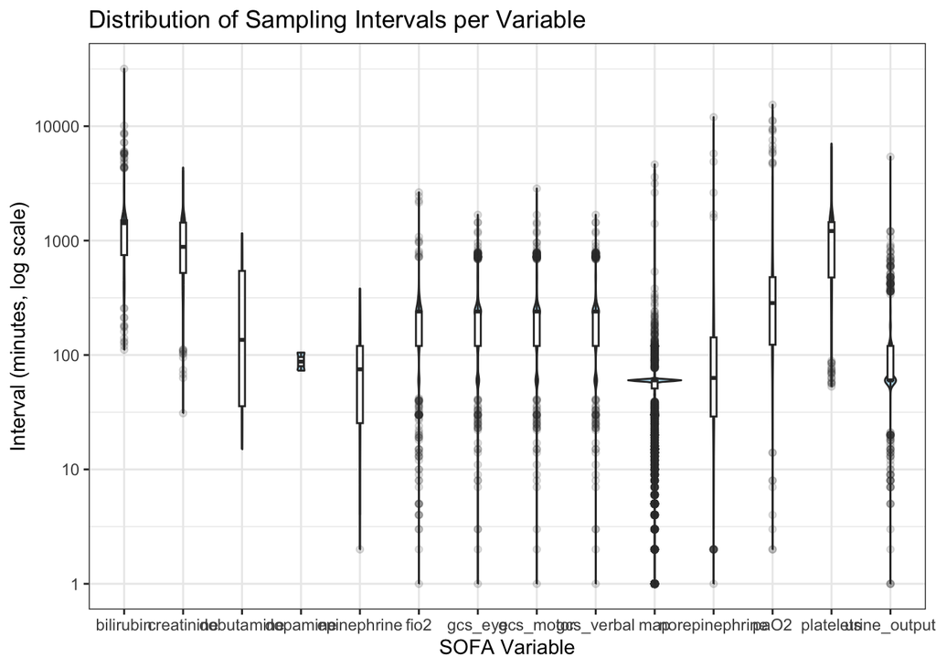

```r
# viz
# violin Plot of sampling intervals (log-scale)

ggplot(intervals, aes(x = var_name, y = diff_mins)) +
  geom_violin(fill = "skyblue", alpha = 0.6) +
  geom_boxplot(width = 0.1, outlier.alpha = 0.15) +
  scale_y_log10() +
  theme_bw() +
  labs(
    title = "Distribution of Sampling Intervals per Variable",
    x = "SOFA Variable",
    y = "Interval (minutes, log scale)"
  )
```

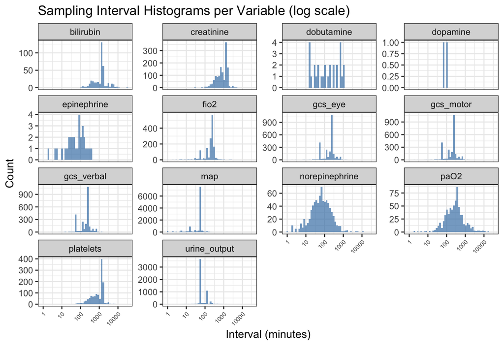

```r
ggplot(intervals, aes(x = diff_mins)) +
  geom_histogram(bins = 50, fill = "steelblue", alpha = 0.7) +
  scale_x_log10() +
  facet_wrap(~ var_name, scales = "free_y") +
  theme_bw() +
  theme(
    plot.margin = margin(5.5, 5.5, 20, 5.5),  # extra room bottom
    axis.text.x = element_text(angle = 45, hjust = 1, size = 6)
  ) +
  labs(
    title = "Sampling Interval Histograms per Variable (log scale)",
    x = "Interval (minutes)",
    y = "Count"
  )
```

```r
# 2.c) procedural search to identify SOFA change >= 2
```

[output not shown]

### 3.3 Temporal Alignment and Grouping

Accurate temporal alignment is critical for causal inference in clinical settings, which includes three significant alignment procedures. 1) Sepsis Onset, defined as the earliest time when both infection and SOFA >= 2 criteria are satisfied; 2) Antibiotic Administration, timestamped from *prescriptions.starttime* or *inputeevents.starttime*. 3) Time-to-Antibiotic: Computed as the difference between antibiotic initiation and sepsis onset.

Patients will be categorized into Early (TTA <= 3 hours) and late (TTA >= 3 hours) treatment groups, consistent with Surviving Sepsis Campaign (SSC) guidelines. Sensitivity analyses will explore alternate thresholds (e.g., 1h, 6h) to assess robustness).

## 6 Reference

https://pmc.ncbi.nlm.nih.gov/articles/PMC4968574/

https://ieeexplore.ieee.org/stamp/stamp.jsp?tp=&arnumber=10803371

https://pubmed.ncbi.nlm.nih.gov/26903338/

https://pubmed.ncbi.nlm.nih.gov/8844239/